# homework1

Collin

10/14/2020

# 1 **Vectors and Simulations**

- **a)** *Generate random samples with replacement of size 100 from each of the types. Call the resulting vectors of character strings as: Animal, Color, Attribute (1 point).*

```r
animals = c("cat","dog","cow","squirrel")
colors = c("white","black","brown","red")
attr = c("big","small","angry","cute", "finicky")

Animal = sample(animals,100, replace = TRUE)
Color = sample(colors,100,replace= TRUE)
Attribute = sample(attr,100,replace = TRUE)
Animal
```

```
##   [1] "cow"      "dog"      "squirrel" "squirrel" "dog"      "squirrel"
##   [7] "cow"      "squirrel" "cat"      "squirrel" "dog"      "squirrel"
##  [13] "dog"      "cat"      "dog"      "cat"      "cow"      "dog"
##  [19] "cow"      "dog"      "dog"      "dog"      "cat"      "dog"
##  [25] "cat"      "squirrel" "cat"      "squirrel" "cat"      "cat"
##  [31] "cow"      "dog"      "cow"      "cow"      "squirrel" "dog"
##  [37] "dog"      "cow"      "cow"      "dog"      "squirrel" "dog"
##  [43] "dog"      "cat"      "squirrel" "dog"      "cow"      "squirrel"
##  [49] "cat"      "dog"      "squirrel" "squirrel" "cat"      "cat"
##  [55] "squirrel" "cat"      "cat"      "cat"      "squirrel" "cow"
##  [61] "dog"      "dog"      "squirrel" "dog"      "dog"      "dog"
##  [67] "squirrel" "squirrel" "dog"      "cat"      "cat"      "dog"
##  [73] "cow"      "dog"      "squirrel" "squirrel" "cow"      "squirrel"
##  [79] "cow"      "cow"      "cow"      "dog"      "dog"      "cow"
##  [85] "squirrel" "cow"      "cat"      "squirrel" "cow"      "dog"
##  [91] "squirrel" "squirrel" "cat"      "cat"      "dog"      "cat"
##  [97] "squirrel" "cat"      "dog"      "cat"
```

```r
Color
```

```
##   [1] "red"   "white" "brown" "black" "white" "red"   "black" "brown" "red"
##  [10] "black" "black" "brown" "black" "brown" "brown" "red"   "red"   "white"
##  [19] "black" "black" "brown" "red"   "white" "brown" "red"   "white" "brown"
##  [28] "brown" "white" "black" "white" "black" "black" "red"   "white" "brown"
##  [37] "white" "brown" "white" "red"   "red"   "white" "white" "red"   "white"
##  [46] "white" "white" "red"   "red"   "red"   "black" "brown" "black" "red"
##  [55] "black" "red"   "brown" "white" "black" "white" "white" "red"   "red"
##  [64] "black" "black" "red"   "red"   "black" "white" "white" "black" "brown"
##  [73] "black" "red"   "brown" "red"   "white" "white" "white" "brown" "red"
##  [82] "red"   "black" "white" "brown" "black" "brown" "red"   "black" "brown"
##  [91] "brown" "red"   "red"   "black" "red"   "black" "white" "red"   "white"
## [100] "brown"
```

```r
Attribute
```

```
##   [1] "cute"    "angry"   "finicky" "cute"    "angry"   "finicky" "finicky"
##   [8] "small"   "cute"    "cute"    "big"     "small"   "big"     "cute"
##  [15] "finicky" "big"     "finicky" "cute"    "finicky" "big"     "finicky"
##  [22] "angry"   "small"   "finicky" "cute"    "big"     "cute"    "small"
##  [29] "angry"   "finicky" "cute"    "cute"    "finicky" "big"     "cute"
##  [36] "small"   "angry"   "big"     "finicky" "cute"    "small"   "angry"
##  [43] "finicky" "big"     "cute"    "small"   "cute"    "small"   "small"
##  [50] "cute"    "big"     "angry"   "finicky" "cute"    "finicky" "finicky"
##  [57] "big"     "finicky" "cute"    "small"   "cute"    "big"     "finicky"
##  [64] "small"   "cute"    "cute"    "finicky" "big"     "cute"    "small"
##  [71] "cute"    "big"     "cute"    "finicky" "angry"   "angry"   "small"
##  [78] "cute"    "finicky" "angry"   "big"     "angry"   "small"   "big"
##  [85] "finicky" "big"     "finicky" "finicky" "big"     "big"     "big"
##  [92] "small"   "big"     "cute"    "big"     "finicky" "finicky" "finicky"
##  [99] "cute"    "angry"
```

- **b)** *Compute how many animals in the sample are cats or dogs (1 point).*

```r
count = 0
for(anim in Animal){
  if (anim == "cat" | anim == "dog"){
    count = count + 1
  }
}
count
```

```
## [1] 54
```

- **c)** *Write R code to combine the results to produce phrases (character strings) describing the animals as in this example: big white dog (2 points).*

```r
#attribute color animal
listOfVecs = list(attr, colors, animals)
randomPhraseVector = c()
for(vector in listOfVecs){
  appendWord = sample(vector,1)
  randomPhraseVector = append(randomPhraseVector,appendWord)

}
paste(randomPhraseVector)
```

```
## [1] "finicky"  "red"      "squirrel"
```

- **d)** *Create a contingency table between Animal and Attribute (1 point).*

```r
library(dplyr)
contingTable = table(Animal,Attribute)
contingTable
```

```
##           Attribute
## Animal     angry big cute finicky small
##   cat          2   4    7       7     3
##   cow          1   6    4       6     2
##   dog          6   7    9       5     4
##   squirrel     3   4    6       8     6
```

# **2 Matrices**

- **a)** *Create the matrix A and the vector y corresponding to the matrix equation Ax=y,where A∈ℝ5×5 and x,y∈ℝ5 (1 point).*

```r
A = matrix(c(1,2,3,4,5,
             2,1,2,3,4,
             3,2,1,2,3,
             4,3,2,1,2,
             5,4,3,2,1),5,5,byrow = TRUE)

A
```

```
##      [,1] [,2] [,3] [,4] [,5]
## [1,]    1    2    3    4    5
## [2,]    2    1    2    3    4
## [3,]    3    2    1    2    3
## [4,]    4    3    2    1    2
## [5,]    5    4    3    2    1
```

```r
y = c(7,-1,-3,5,17)
```

- **b)** *Determine if the matrix A is invertible (2 points).*

```r
if(det(A)!=0){
  print("Matrix A is invertible")

}else{
  print("The matrix is NOT invertible")
}
```

```
## [1] "Matrix A is invertible"
```

- **c)** *Find the solution of the system of linear equations (2 points).*

```r
solve(A,y)
```

```
## [1] -2  3  5  2 -4
```

```r
#or
colnames(A) <- paste0('x', 1:5)

solve(A) %*% y
```

```
##    [,1]
## x1   -2
## x2    3
## x3    5
## x4    2
## x5   -4
```

- **d)** *Verify that your solution is correct (1 point).*

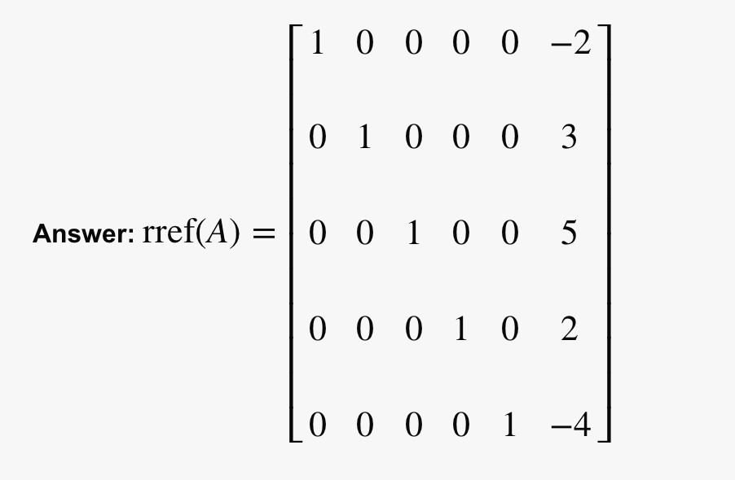

I verified the solution using eMathHelps RREF calculator online: .

## **3 Data Exploration**

```r
#load data
load("/Users/collinkennedy/Google Drive/Programming Folder (4Transfer to Collin's Files V2)/R/STA141A/countypop.RData")
```

**a)** *How many unique 2-letter state abbreviations are there (1 point)?*

```r
vecOfAbbrevs <- unique(countypop$abbr)
length(vecOfAbbrevs)
```

```
## [1] 51
```

there are 51 unique abbreviations (this makes sense since the data includes DC)

**b)** *What is the total number of counties in the US (1 point)?*

```r
length(countypop$county)
```

```
## [1] 3142
```

There are 3142 counties in the US.

**c)** *How many unique county names are there (1 point)?*

```r
vecOfUniqueCounties = unique(countypop$county)
length(vecOfUniqueCounties)
```

```
## [1] 1877
```

There are 1877 *unique* county names.

**d)** *What are the top 10 most common county names (2 points)?*

```r
countyFreq <- as.data.frame(table(countypop$county))
countyFreq = countyFreq %>% arrange(desc(Freq))
#top 10 most common county names:
countyFreq[1:10,]
```

```
##                 Var1 Freq
## 1  Washington County   30
## 2   Jefferson County   25
## 3    Franklin County   24
## 4     Jackson County   23
## 5     Lincoln County   23
## 6     Madison County   19
## 7        Clay County   18
## 8  Montgomery County   18
## 9      Marion County   17
## 10     Monroe County   17
```

**e)** *Which state has the largest number of counties? Which state has the smallest number of counties (1 points)?*

```r
countyAbbr <- as.data.frame(table(countypop$abbr))
countyAbbr  = countyAbbr %>% arrange(desc(Freq))
countyAbbr
```

```
##    Var1 Freq
## 1    TX  254
## 2    GA  159
## 3    VA  133
## 4    KY  120
## 5    MO  115
## 6    KS  105
## 7    IL  102
## 8    NC  100
## 9    IA   99
## 10   TN   95
## 11   NE   93
## 12   IN   92
## 13   OH   88
## 14   MN   87
```

[output cut: 37 more lines]

Texas has the most counties (254), while Delaware has the fewest (3).

**f)** *What is the average population of a county in the US (1 point)?*

```r
mean(countypop$pop_2015)
```

```
## [1] 102297.5
```

**g)** *Which state has the largest county in terms of population? How many people live in the largest county in terms of population (2 points)?*

```r
subDF = countypop %>% arrange(desc(pop_2015))
state = subDF$abbr[1]
#which state
state
```

```
## [1] "CA"
```

```r
#the population in the largest county in that state
pop = subDF$pop_2015[1]
pop
```

```
## [1] 10170292
```

**h)** *What is the largest county in terms of population of each of the states (2 points)?*

```r
hDF2 = countypop %>%
  group_by(abbr) %>%
  filter(abbr != "DC") %>%
  slice(which.max(pop_2015)) %>%
  arrange(desc(pop_2015)) %>% #slice selects rows by position->in this case
  print(n=50)                         #it chooses the greatest population value of each county
```

```
## # A tibble: 50 x 4
## # Groups:   abbr [50]
##    fips  abbr  county                  pop_2015
##    <chr> <chr> <chr>                      <dbl>
##  1 06037 CA    Los Angeles County      10170292
##  2 17031 IL    Cook County              5238216
##  3 48201 TX    Harris County            4538028
##  4 04013 AZ    Maricopa County          4167947
##  5 12086 FL    Miami-Dade County        2693117
##  6 36047 NY    Kings County             2636735
##  7 53033 WA    King County              2117125
##  8 32003 NV    Clark County             2114801
##  9 26163 MI    Wayne County             1759335
## 10 25017 MA    Middlesex County         1585139
## 11 42101 PA    Philadelphia County      1567442
```

[output cut: 39 more lines]

```r
                            #since we are grouping by State (abbr)
```

**i)** *What is the average population of the 100 largest counties in the US (2 points)?*

```r
countyPopByPop = countypop %>% arrange(desc(pop_2015))
mean(countyPopByPop$pop_2015[1:100])
```

```
## [1] 1370079
```

**j)** *How many people live in each of the states (2 points)?*

```r
totalPopDF = group_by(countypop, abbr) %>%
  summarize(totalPopulation = sum(pop_2015)) %>%
  filter(abbr != "DC") %>%
  arrange(desc(totalPopulation))
print(totalPopDF, n= 50)
```

```
## # A tibble: 50 x 2
##    abbr  totalPopulation
##    <chr>           <dbl>
##  1 CA           39144818
##  2 TX           27469114
##  3 FL           20271272
##  4 NY           19795791
##  5 IL           12859995
##  6 PA           12802503
##  7 OH           11613423
##  8 GA           10214860
##  9 NC           10042802
## 10 MI            9922576
## 11 NJ            8958013
## 12 VA            8382993
```

[output cut: 38 more lines]

**k)** *What is the average population of a county in California (2 points)?*

```r
caliDF = countypop %>% filter(abbr == "CA")
#average population of a county in California:
mean(caliDF$pop_2015)
```

```
## [1] 674910.7
```

**l)** *What is the average population of a county in each of the states (2 points)?*

```r
meanPopDF = group_by(countypop, abbr) %>%
  summarize(meanPopulationOfACounty = mean(pop_2015)) %>%
  filter(abbr != "DC") %>%
  arrange(desc(meanPopulationOfACounty))
print(meanPopDF, n= 50)
```

```
## # A tibble: 50 x 2
##    abbr  meanPopulationOfACounty
##    <chr>                   <dbl>
##  1 CA                    674911.
##  2 MA                    485316.
##  3 AZ                    455204.
##  4 CT                    448861.
##  5 NJ                    426572.
##  6 NY                    319287.
##  7 DE                    315311.
##  8 FL                    302556.
##  9 HI                    286321.
## 10 MD                    250267.
## 11 RI                    211260.
## 12 PA                    191082.
```

[output cut: 38 more lines]